# Bayou Workshop Notebook

Welcome to the SSB 2017 *bayou* Workshop!

```r
library(devtools)
library(geiger)
library(phytools)
library(foreach)
library(doParallel)
library(treeplyr)
#install_github("uyedaj/bayou", ref = "dev")
library(bayou)
```

# Simulating a multi-optima OU process on a phylogeny

Let’s begin by simulating a multi-optimum Ornstein-Uhlenbeck process on a phylogeny so that we can get a feel for how these models work to model adaptation on phylognies. First let’s simulate a tree and rescale it to 100 million years. The second step is optional, but it will help us make sure all our trees and parameters are on a common scale that will probably be typical of the trees you’ll analyze. We will also reorder the tree into “postorder” format. **bayou** will automatically reorder the tree to postorder format, but it helps to begin by reordering your tree so that the branch numbers used by **bayou** can be easily matched to the tree.

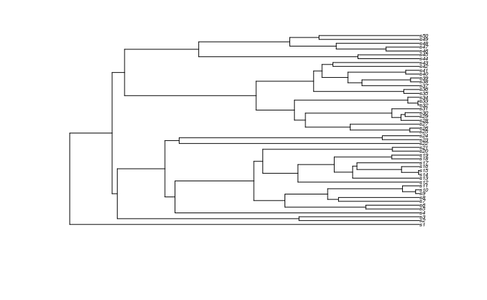

```r
  tree <- sim.bdtree(b = 1, d = 0, stop = "taxa", n = 50, seed = 1)
  tree$edge.length <- tree$edge.length/max(branching.times(tree))*100
  tree <- reorder(tree, "postorder")
  plot(tree, cex = 0.5)
```

```r
NA
```

We are now going to simulate an multi-peak OU process on this tree. bayou stores parameter in a parameter list that at a minimum, expects the parameters:

- alpha
- sig2
- k
- ntheta
- theta
- sb
- t2
- loc

Let’s begin building this list, and then we’ll talk about what each of these parameters means.

```r
simpars <- list(alpha=1, sig2=1, k=2, ntheta=3, theta=c(0,-1,1))
```

*alpha* and *sig2* are familiar parameters from our OU model, as well as our theta parameters with specify the value of the different regime optima. *k* specifies the numbers of shifts on the phylogeny, and *ntheta* specifies the number of optima. If there are no biologically convergent regimes, then ntheta = k + 1 = length(theta). Note that the root optimum is always the first *theta*, but we must provide locations for the other shifts so **bayou** knows where on the tree these occur. Here we can simply specify which branches (*sb*) and where on those branches (*loc*) we would like our shifts to occur.

```r
shiftlocations <- list(sb = c(94, 71), loc = c(6.23, 6.52))
```

However, knowing where the shifts are is easier visually. So alternatively, we can use the **bayou** function *identifyBranches*, which opens an interactive window for clicking where we want the *k* shifts to occur. (Note: identifyBranches does not work with markdown notebooks, so you will have to copy and paste this function into the R console to run)

```r
shiftlocations <- identifyBranches(tree, simpars$k) ## Copy and paste into the console, run interactively.
```

We now combine the lists to obtain our full parameter list.

```r
simpars <- c(simpars, shiftlocations)
simpars$t2 <- 2:3
simpars
```

```
$alpha
[1] 1

$sig2
[1] 1

$k
[1] 2

$ntheta
[1] 3

$theta
[1]  0 -1  1

$sb
[1] 94 71

$loc
[1] 6.215961 5.479150

$t2
[1] 2 3
```

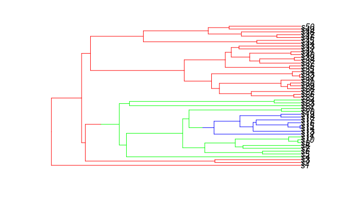

```r
plotBayoupars(simpars, tree)
```

The *$sb* element to the list specifies which branches the shifts occur on (assuming the tree is postordered). The length of *$sb*, *$t2* and *$loc* must equal *$k*. The element *$t2* specifies which optimum is shifted to, while *$loc* specifies where on the branch that shift occurs (distance from the node). Now, let’s visualize a complete simulation on the tree:

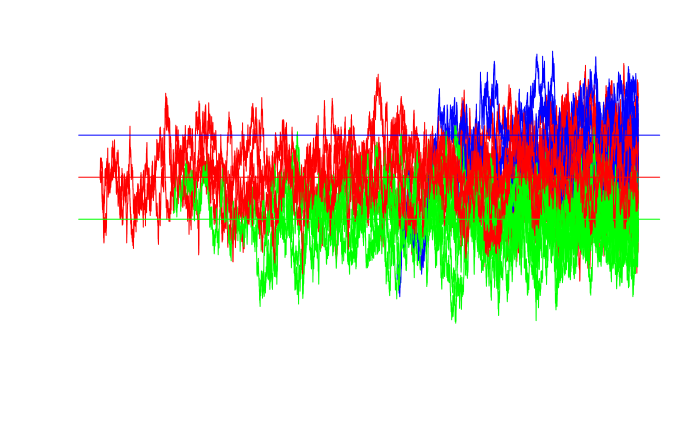

```r
plotOUtreesim(simpars, tree)
abline(h = simpars$theta, col=rainbow(3))
```

#### Questions:

1. What is phylogenetic signal?
2. Looking at this process, would you say this process has high or low phylogenetic signal? (Hint: Consider only within a single regime. If you take 3 species from the red regime, how much more similar will closely related species be than distantly related species?)

Modify the parameters to produce more phylogenetic signal.

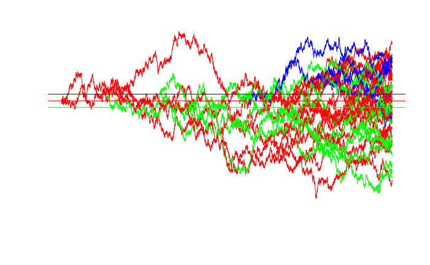

```r
simpars$alpha <- 0.01 #Type one (positive) number
plotOUtreesim(simpars, tree)
abline(h = simpars$theta, col=rainbow(3))
```

Hopefully it now looks like that unique evolutionary history sticks around for longer. But what did it do to the separation between regimes? Why?

Try modifying *sig2* and/or *theta* to restore separation between regimes.

```r
simpars$sig2  <-  0.01          #Type one (positive) number
simpars$theta <- c(0,3, 10)  #Type simpars$ntheta numbers
plotOUtreesim(simpars, tree)
abline(h=seq(-10, 10, 1), lty=3, lwd=0.5)
```

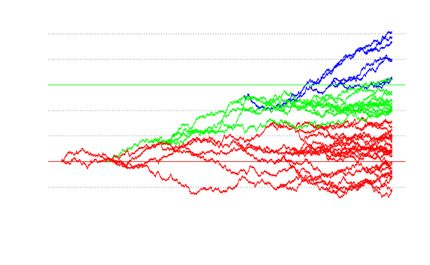

```r
abline(h = simpars$theta, col=rainbow(3))
```

OU models have often come under criticism recently for having flat likelihood ridges and poorly estimated parameters (especially *alpha*). While some of this criticism is valid, it’s important to understand **how the parameters affect the model** and especially, that **the parameters in the model have units**. Thus, setting priors on these parameters to be at least plausible can have a large effect on the model fit, and is a critically important step to a **bayou** analysis.

Brownian Motion, Ornstein-Uhlenbeck models and Early Burst models are Gaussian models. Thus, simply predict the mean and (co)variance of a multivariate normal distribution. We can use some internal functions of **bayou** to visualize how *alpha* affects the expected covariance of an OU/BM model. Let’s plot the expected variance-covariance of a Brownian motion model, which is simply the parameter *sigma^2* times the VCV matrix of the tree (the shared branch lengths between tips). Let’s assume *sigma^2* is 1 or simplicity.

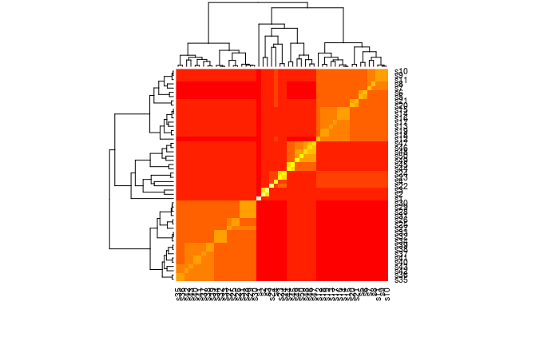

```r
VCV <- vcv.phylo(tree)
heatmap(VCV)
```

In an OU model, it’s not quite so simple. Instead, the covariance between tips degrades over time proportional to the parameter *alpha*. Eventually, given enough time of independent evolution, the covariance will be 0 and the replicate lineages will equilibrate to a stationary variance (*Vy*) equal to *sigma^2/(2 X alpha)*.

Using the internal function of bayou called *.ouMatrix*, we can visualize how these parameters affect the expected covariance.

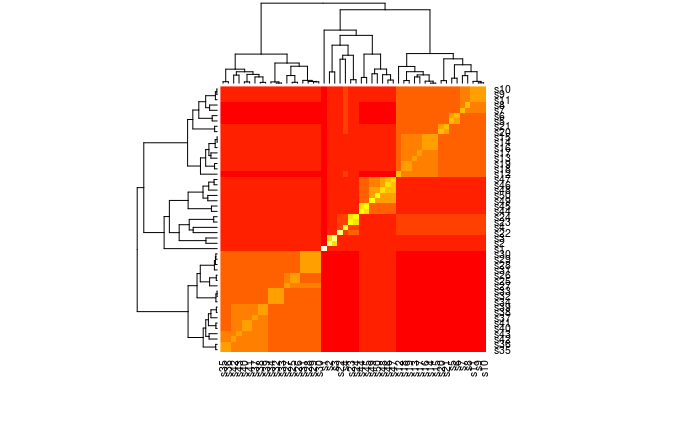

```r
ouV_0.000000001 <- bayou:::.ouMatrix(VCV, alpha = 0.000000001)
ouV_0.0001 <- bayou:::.ouMatrix(VCV, alpha = 0.0001)
ouV_0.001 <- bayou:::.ouMatrix(VCV, alpha = 0.001)
ouV_0.01 <- bayou:::.ouMatrix(VCV,  alpha = 0.01)
ouV_0.1 <- bayou:::.ouMatrix(VCV,  alpha = 0.1)
ouV_1.0 <- bayou:::.ouMatrix(VCV,  alpha = 1)
ouV_10.0 <- bayou:::.ouMatrix(VCV,  alpha = 10)
ouV_100000000.0 <- bayou:::.ouMatrix(VCV,  alpha = 100000000)
heatmap(ouV_0.000000001)
```

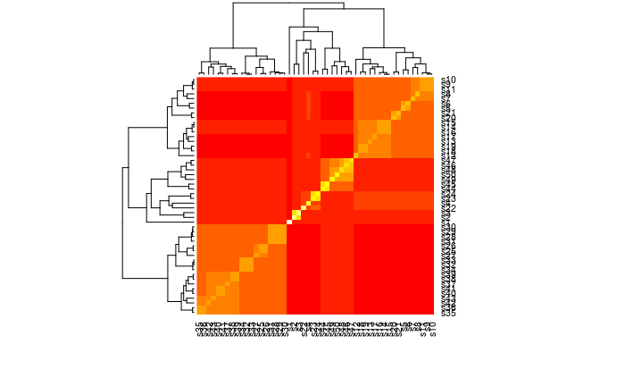

```r
heatmap(ouV_0.0001)
```

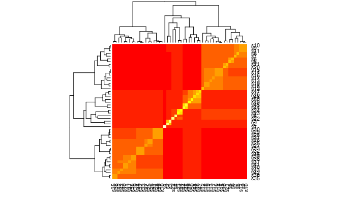

```r
heatmap(ouV_0.001)
```

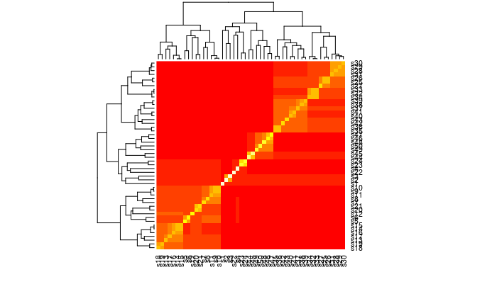

```r
heatmap(ouV_0.01)
```

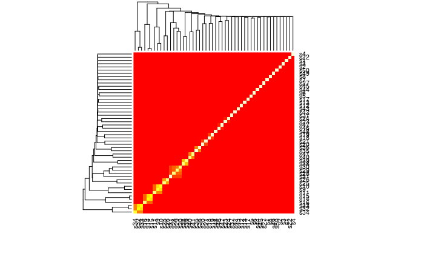

```r
heatmap(ouV_0.1)
```

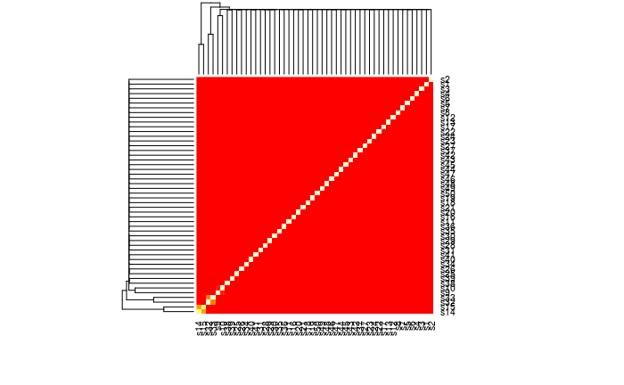

```r
heatmap(ouV_1.0)
```

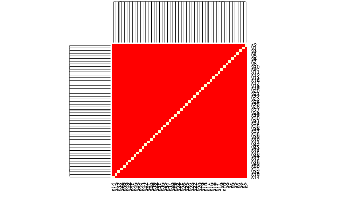

```r
heatmap(ouV_10.0)
```

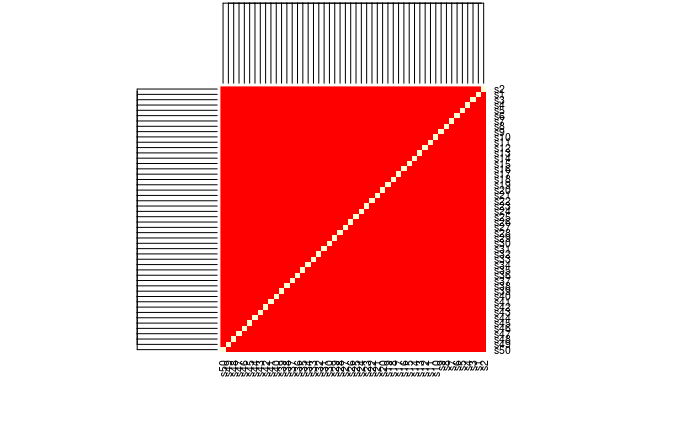

```r
heatmap(ouV_100000000.0)
```

Scroll through the different heat maps and see how different alpha values affect the expected covariance among tips. Do you see much difference between *alpha = 0.000000001* and a value 1,000,000 times larger at *alpha = 0.001*? What about between *alpha = 10* and *alpha = 100,000,000*? Look at how *.ouMatrix* transforms the tree. Why are these different values indistinguishable?

```r
bayou:::.ouMatrix
```

```
function (vcvMatrix, alpha)
{
    vcvDiag <- diag(vcvMatrix)
    diagi <- matrix(vcvDiag, nrow = length(vcvDiag), ncol = length(vcvDiag))
    diagj <- matrix(vcvDiag, nrow = length(vcvDiag), ncol = length(vcvDiag),
        byrow = T)
    Tij = diagi + diagj - (2 * vcvMatrix)
    vcvRescaled = (1/(2 * alpha)) * exp(-alpha * Tij) * (1 -
        exp(-2 * alpha * vcvMatrix))
    return(vcvRescaled)
}
<environment: namespace:bayou>
```

So what values if your optimizer is optimizing *alpha*, and all it knows is that it’s very large or very small, it will have a really tough time finding the correct value! But ultimately, it doesn’t matter much for the predictions of the model. They basically predict the same thing regardless of whether the parameter is large vs. huge (or…tiny vs. miniscule).

We did see a lot of change between what values? Convert these to phylogenetic half-life and compare to the height of the tree. What do you conclude about the range of *alpha* values that are distinguishable?

###### Challenge question

1. Consider the following scenarios, how would you generate them by changing the parameters of an OU model (if at all)?
- Brownian Motion with a trend (i.e. phylogenetic covariance that never goes away, but regimes that slowly and continuously get pulled apart in different directions.)
- White noise with extremely narrow adaptive zones (i.e. very little phylogenetic covariance within regimes, very small stationary variance)
- Brownian Motion with sudden jumps (i.e. phylogenetic covariance that never goes away, but sudden shifts)
- Lineages very close to their adaptive optima with very large amounts of phylogenetic signal and very narrow adaptive zones.

# Using bayou

Now that we have some intuition as to how OU models work, let’s simulate some data and use **bayou** to estimate adaptive shifts on phylogenies. Let’s first define a set of parameter values to use to simulate our data.

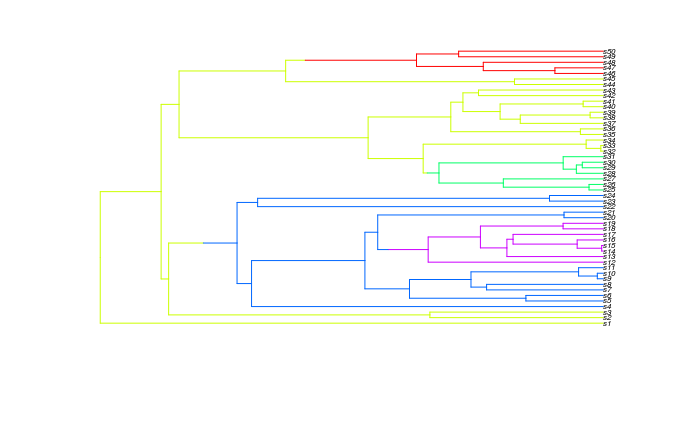

```r
set.seed(1)
truepars <- list(alpha=0.1, sig2=0.1,
                    k=4, ntheta=5, theta=rnorm(5, 0, 4))
trueshiftlocations <- list(sb = c(94, 71, 45, 12), loc = c(6.9, 2.2, 0.8, 3.9)) # I encourage you to use identifyBranches instead.
truepars <- c(truepars, trueshiftlocations)
truepars$t2 <- 2:5
plotBayoupars(truepars, tree, cex = 0.5)
```

Now using the function *dataSim*, we can simulate trait data.

```
[1] "Using mapped regimes from parameter list"
```

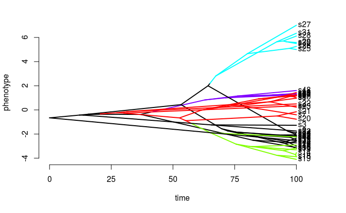

```r
dat <- dataSim(truepars, tree, model="OU")$dat
```

To add realism, let’s add some measurement error to the data. This is a good reminder to *always try to use measurement error in your analyses*. OU models especially are affected by measurement error. This is because OU models have the effect of “erasing” evolutionary history with increasing *alpha*. If you don’t account for measurement error, then that measurement error will be transferred to the evolutionary process model. You can make a Brownian Motion model look very OU like if there is a lot of measurement error.

```r
MEvar <- 0.1
dat <- dat + rnorm(length(dat), 0, sqrt(MEvar))
```

We can now define our prior for our model. The prior function is going to take our parameters and output the *prior probability* of our parameter values. It represents our initial degree of belief in what values the parameters will take.

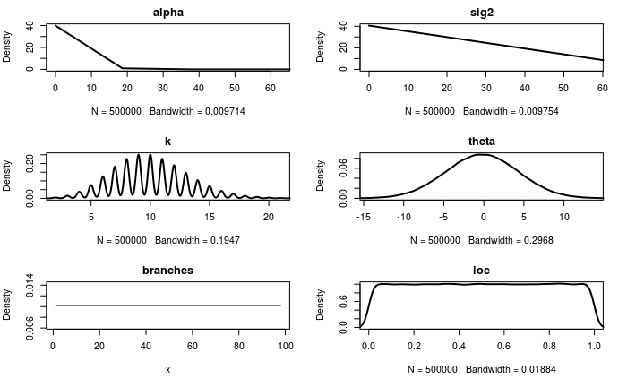

```r
priorOU <- make.prior(tree,
                      dists=list(dalpha="dhalfcauchy", dsig2="dhalfcauchy",
                                 dk="cdpois", dtheta="dnorm"),
                      param=list(dalpha=list(scale=0.1), dsig2=list(scale=0.1),
                                 dk=list(lambda=10, kmax=50), dsb=list(bmax=1, prob=1),
                                 dtheta=list(mean=mean(dat), sd=1.5*sd(dat)))
)
```

*make.prior* tries to be reasonable and not make you type everything out, but **do not be comfortable with defaults**. One trick to make sure your prior functions are reasonable is to simulate a bunch of values and take the quantiles of the distribution. We are using a half-Cauchy distribution for *alpha* and *sig2*, which is a good weakly informative prior for scale parameters.

Let’s see what our choice of half-Cauchy distribution means for our prior on the phylogenetic half-life for the model:

```r
quantiles <- c(0, 0.01, 0.025, 0.25, 0.5, 0.75, 0.975, 0.99, 1)
alfs <- rhalfcauchy(10000, scale = 0.1)
qs <- quantile(log(2)/alfs, quantiles) ## Use 'alfs' and math to calculate the quantiles of phylogenetic half-life
round(qs, 2)
```

```
       0%        1%      2.5%       25%       50%       75%     97.5%
     0.00      0.10      0.27      2.95      7.13     17.42    170.38
      99%      100%
   415.21 171605.49
```

Remember our tree is 100 million years old. So we’re saying that the median value is around 7 million years, and about 75% of the prior density is on a model with fairly short half-lives (< half the tree height). Even so, we are still allowing Brownian Motion-like half-lives (i.e. half-lives longer than the height of the tree).

To run our MCMC, we have to initiate the MCMC chain with some starting values. It’s good to run multiple chains from multiple different starting values. Let’s simulate some values from the prior distribution and make sure our prior functions works.

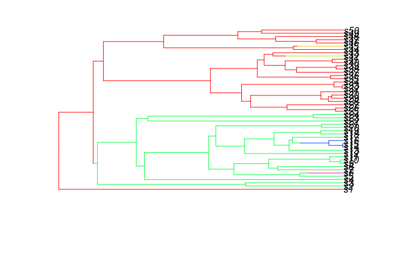

```r
startpars <- priorSim(priorOU, tree, plot=TRUE)$pars[[1]]
```

```r
priorOU(startpars)
```

```
[1] -47.45817
```

We’re now going to take what we have and put it into the function *bayou.makeMCMC*. This function does not immediately initiate the MCMC, but it makes an object that we can use to manage our MCMC analysis. When *bayou* runs an MCMC, it writes the output to a set of files that need to put somewhere. This ensures that the memory doesn’t get full of increasingly long chains. Here, I’ve specified the directory “../output/modelOU/”. You’ll have to make sure that the directory “../output/” exists for this line to work.

```r
set.seed(1)
mcmcOU <- bayou.makeMCMC(tree, dat, SE=MEvar, prior=priorOU,
                         new.dir="../output/modelOU/", outname="modelOU_r001", plot.freq=NULL) # Set up the MCMC
```

[output not shown]

The full MCMC results are written to a set of files. We can load them back in to R as follows.

```r
chainOU <- mcmcOU$load()
```

Let’s take a look at the results. We can set a “burnin” parameter that tells the package **coda** to discard the first bit of the chain.

```r
chainOU <- set.burnin(chainOU, 0.3)
summary(chainOU)
```

```
bayou MCMC chain: 16650 generations
1666 samples, first 500 samples discarded as burnin


Summary statistics for parameters:
                   Mean         SD     Naive SE Time-series SE
lnL        -40.60717352 3.60990143 0.1056719972    0.712451614
prior      -51.57439266 8.05223169 0.2357115341    1.333539370
alpha        0.08141224 0.04750320 0.0013905527    0.014771499
sig2         0.05786817 0.03141806 0.0009196952    0.008426231
k            8.31191088 1.60788805 0.0470674185    0.262222233
ntheta       9.31191088 1.60788805 0.0470674185    0.262222233
root.theta  -2.27688831 0.21120225 0.0061824856    0.032585723
all theta    0.19501251 3.71881500           NA             NA
           Effective Size   HPD95Lower  HPD95Upper
lnL              25.67320 -46.91953510 -33.7384932
prior            36.46035 -68.13431741 -39.1069894
alpha            10.34181   0.03350178   0.1862212
sig2             13.90247   0.02424815   0.1366064
k                37.59868   5.00000000  11.0000000
ntheta           37.59868   6.00000000  12.0000000
root.theta       42.00900  -2.66648307  -1.9316704
all theta              NA           NA          NA


Branches with posterior probabilities higher than 0.1:
          pp magnitude.of.theta2 naive.SE.of.theta2 rel.location
94 1.0000000           0.5624422        0.006644058   0.52282729
12 0.9785775           1.5944033        0.013888756   0.57927676
45 0.8320480           7.3645793        0.029797200   0.78524469
71 0.6118252          -3.5157677        0.023374057   0.37689322
70 0.4138817          -4.1585237        0.028064602   0.49888795
69 0.3933162          -3.4138091        0.036660040   0.49306177
72 0.3119109          -0.4120690        0.037426189   0.47234396
46 0.2536418          -2.1062010        0.029011555   0.41714154
59 0.2356470           3.6652446        0.220267347   0.04950197
47 0.2185090           4.0564857        0.191243947   0.32062309
80 0.1396744           1.3840596        0.043432597   0.38541766
52 0.1208226           1.9044176        0.086502408   0.17229993
93 0.1096829          -1.5828592        0.031173568   0.53488204
54 0.1036847           0.6020822        0.038206123   0.47260483
```

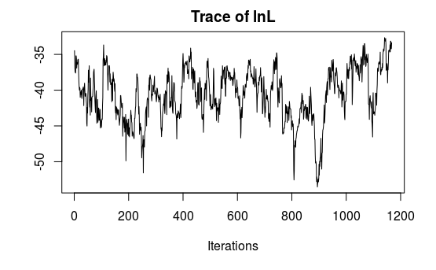

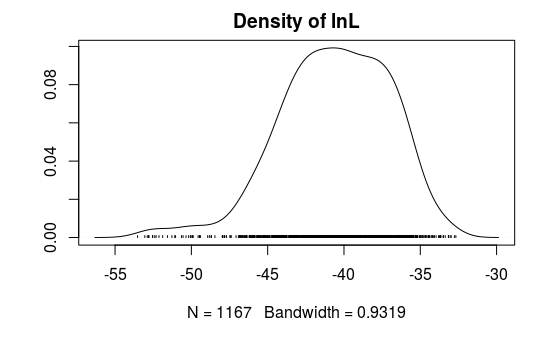

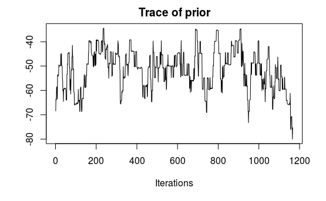

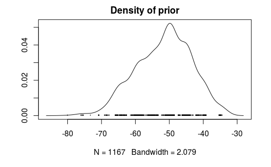

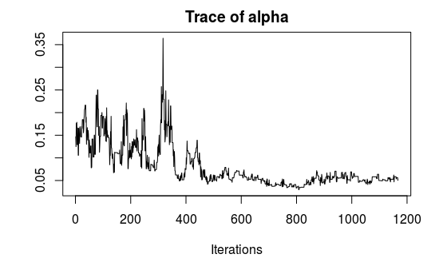

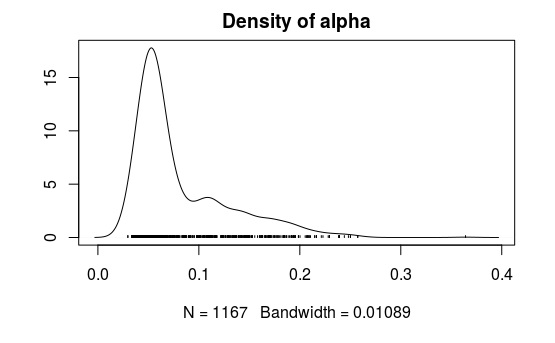

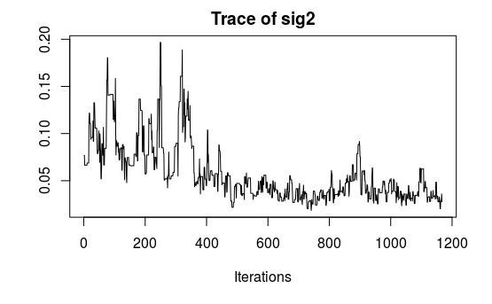

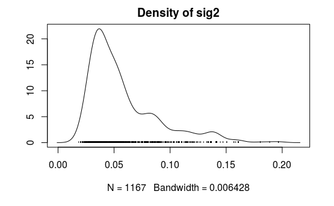

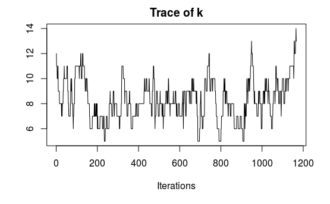

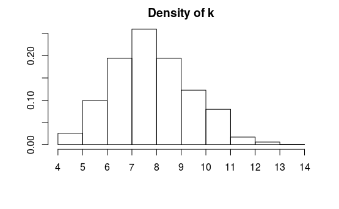

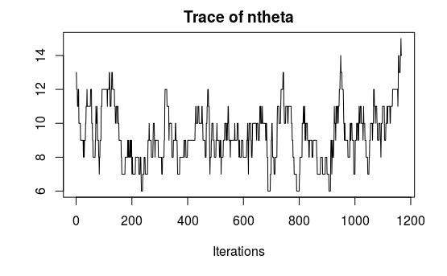

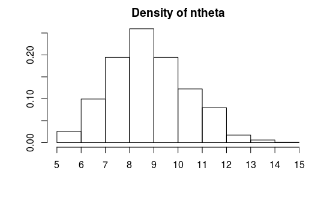

[2 more figures not shown]

```r
plot(chainOU, auto.layout=FALSE)
```

Let’s visualize what we have so far. First, we will plot the truth, then 3 alternative ways of visualizing our chain.

```r
par(mfrow=c(2,2))
plotBayoupars(truepars, tree, main = "True parameters")
plotSimmap.mcmc(chainOU, burnin = 0.3, pp.cutoff = 0.3)
```

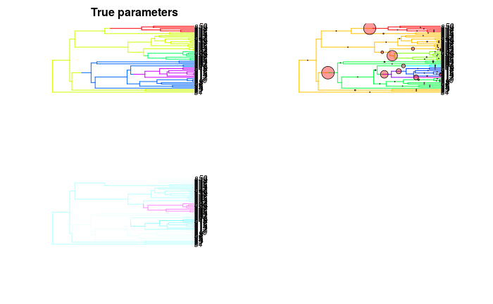

```r
plotBranchHeatMap(tree, chainOU, "theta", burnin = 0.3, pal = cm.colors)
phenogram.density(tree, dat, burnin = 0.3, chainOU, pp.cutoff = 0.3)
```

[output not shown]

Even though we haven’t gotten convergence yet, we’re probably picking up the major shifts pretty well.

# Alternative parameterizations

Two alternative parameterizations of the OU model are built into **bayou**. First, is a parameterization where priors can be placed directly on phylogenetic half-life (*halflife*) and stationary variance (*Vy*), rather than *alpha* and *sig2*. For example, let’s say we want to have a mildly informative prior on the phylogenetic half-life–say a log-normal distribution:

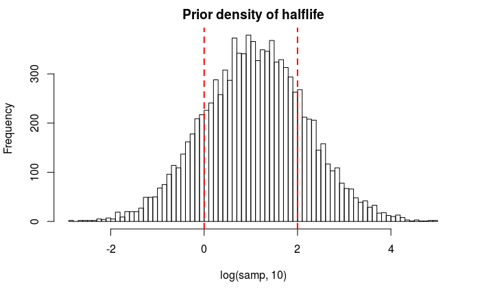

```r
par.halflife <- list(meanlog=2.5, sdlog=2.5)
#Draw a bunch of samples from this distribution:
samp <- rlnorm(10000, par.halflife$meanlog, par.halflife$sdlog)
hist(log(samp,10), breaks=100, main="Prior density of halflife")
abline(v=log(c(1,max(branching.times(tree))),10), col="red", lwd=2, lty=2)
```

Notice that there is about equal density of prior probability on the half-life being greater than tree height (rightmost red line) as there is below 1 million years (leftmost red line). The exact quantiles of this distribution are:

```r
qs <- qlnorm(quantiles, meanlog=par.halflife$meanlog, sdlog=par.halflife$sdlog)
round(setNames(qs, quantiles), 2)
```

```
      0    0.01   0.025    0.25     0.5    0.75   0.975    0.99       1
   0.00    0.04    0.09    2.26   12.18   65.77 1635.84 4088.24     Inf
```